# Visualization of COVID19 Data in Bicol

Ateneo REGIS Hub

August 10, 2020

## Visualization of COVID19-related Data from Bicol Region and Naga City, Camarines Sur, Philippines

*Data sources used to make the plots are official press releases of DOH CHD - Bicol and official releases from the COVID Tracker of the Local Government of Naga, official statements of the Office of the Mayor of the concerned LGUs.*

The following interactive plot shows the **Covid19-positive individuals and their contacts** in **Bicol Region** as of **August 9, 2020**.

**Use your mouse to zoom in to particular cases, see details, and look into connections.**

[interactive chart not shown]

## Time Varying R in Bicol Region as of **August 9, 2020**

The following figure shows the output plots: **Epidemic Curve, Estimated R, and Explored Serial Interval Distribution**

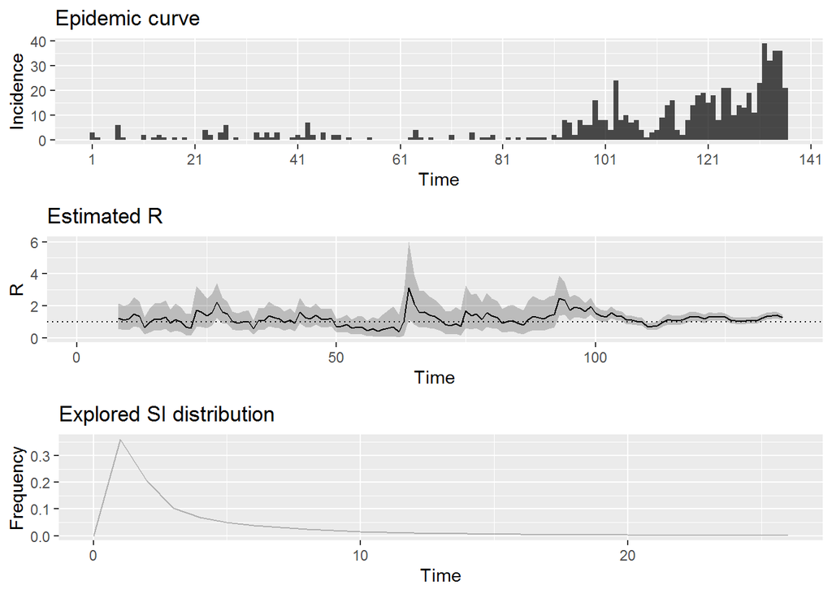

### References:

**R Core Team (2017). R: A language and environment for statistical computing. R Foundation for Statistical Computing, Vienna, Austria. URhttps://www.R-project.org/**

**packages used: dplyr, data.table, lubridate, reshape2, ggplot2, EpiEstim, epicontacts, googlesheets4, readxl**

**Help us improve our viz. Send a pull request at [link](https://github.com/shanebimeda/regishub)**

H. Wickham. ggplot2: Elegant Graphics for Data Analysis. Springer-Verlag New York, 2016

Matt Dowle and Arun Srinivasan (2019). data.table: Extension of `data.frame`. R package version 1.12.8. https://CRAN.R-project.org/package=data.table